# Informe Mensual de las cotizaciones

Unidad de Gestión Pensional y Parafiscales - UGPP

[figure not shown]

# Proposito del informe

- Contar con información detallada sobre la evolución de los aportes a seguridad social de los colombianos, como insumo fundamental para la toma de decisiones de política pública.
- Identificar el comportamiento de empresas y personas naturales frente a la crisis, y evidenciar grupos poblacionales vulnerables.
- Generar esquemas de relación diferenciada de la UGPP con los aportantes, reconociendo su realidad particular.

# Consideraciones técnicas

- La información presenta dos desagregaciones temáticas: cotizantes independientes y dependientes. Así mismo, hace énfasis en los dependientes de sector privado, donde se usa una base construida por la UGPP de entidades y empresas públicas, con información pública: SECOP, DATOS.GOV, Entidades Territoriales, Base de empresas DIAN (ENVIADA MIN HACIENDA), y los tipos de afiliación 1 (dependiente), 2 (servicio doméstico) y 22 (profesor particular).
- Los montos de cotización son la suma de los aportes de pensiones, salud, ARL, CCF, parafiscales SENA y ICBF en cada relación laboral.
- La actividad económica se toma de la actualización más reciente del Registro Único Tributario – RUT. Cuando no es posible el cruce con RUT, se toma información de actividad económica de PILA.
- La información de ubicación de las personas se toma de la Caja de Compensación familiar y la información de fecha de nacimiento y sexo se toma de la base de RUAF a la fecha de corte de publicación

# Introcucción

## Año tipo 2012 - 2019

### Estimación interanual de las cotizaciones

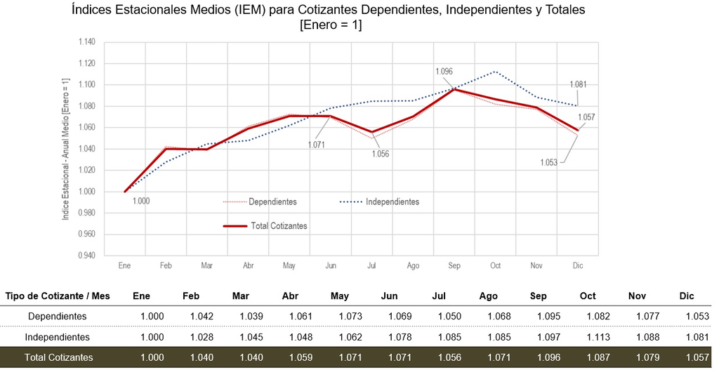

### Estimación de los cotizantes en cada Enero para la estimación.

El IEM esta en función del número de cotizantes para el periodo de enero de cada año, ante esto es indispensable contar con la estimación de las cotizaciones para enero de 2021 con el fin de conocer el total esperado para cada mes de este año.

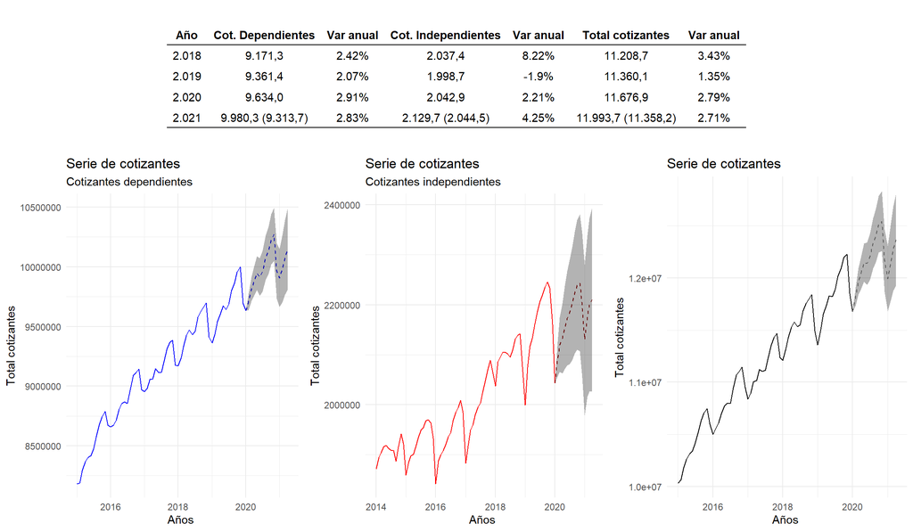

## Total cotizantes

Comportamiento del periodo de análisis

| Año | Total cotizantes | Total cotizantes Var anual | Total cotizantes Var mensual | Dependientes Total cotizantes | Dependientes Var anual | Dependientes Var mensual | Independientes Total cotizantes | Independientes Var anual | Independientes Var mensual |
| --- | --- | --- | --- | --- | --- | --- | --- | --- | --- |
| 2021 | 12.321,3 | 5,02% | -4,62% | 10.164,0 | 6,47% | -4,54% | 2.157,4 | -1,32% | -4,99% |
| 2020 | 11.732,7 | -2,42% | -2,02% | 9.546,5 | -3,13% | -2,16% | 2.186,1 | 0,82% | -1,39% |
| 2019 | 12.023,7 | 3,96% | -4,49% | 9.855,3 | 3,85% | -4,72% | 2.168,4 | 4,49% | -3,47% |
| 2018 | 11.565,5 | 0,00% | -4,83% | 9.490,4 | 0,00% | -5,11% | 2.075,1 | 0,00% | -3,48% |

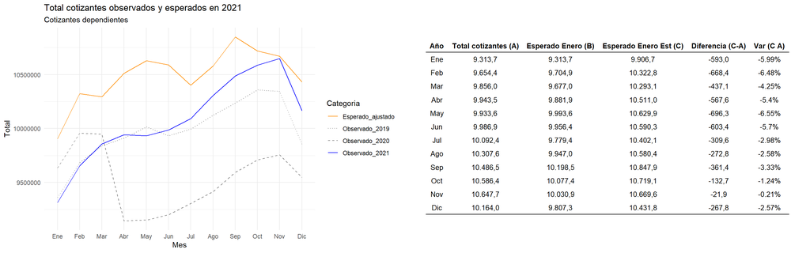

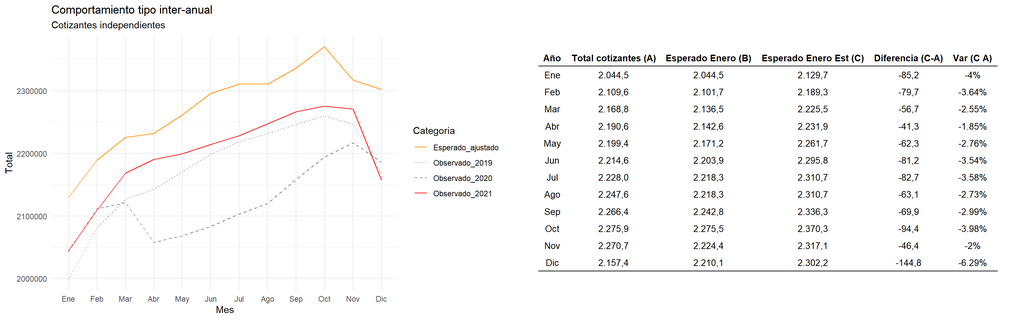

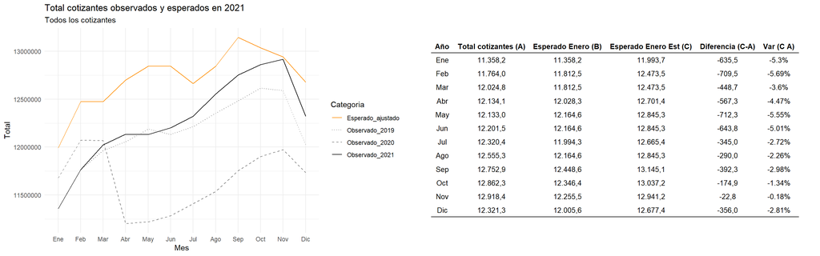

## Distribución por Rango Salarial

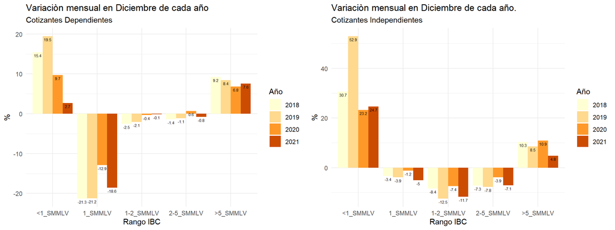

Total, diferencia mensuales y anuales de los cotizantes en diciembre 2021

[output not shown]

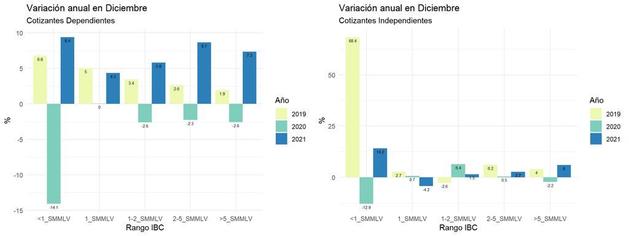

## Comportamiento de las novedades

### Dependientes

Para el periodo de Diciembre 2021 las novedades de ingreso, retiro, suspención temporal y vacaciones fueron de 695.025, 1.398.794, 274.239 y 1.436.869 respectivamente con variaciones mensuales de -20,7%, 34,6%, 10,4% y 275,9%.

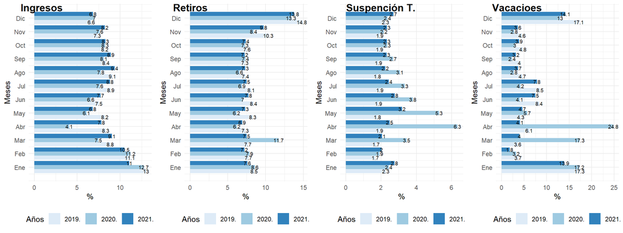

Variaciones anuales de novedades de ingreso, retiro, suspension temporales y vacaciones

| Mes | Ingresos 2019 | Ingresos 2020 | Ingresos 2021 | Retiros 2019 | Retiros 2020 | Retiros 2021 | Suspensiones temporales 2019 | Suspensiones temporales 2020 | Suspensiones temporales 2021 | Vacaciones 2019 | Vacaciones 2020 | Vacaciones 2021 |
| --- | --- | --- | --- | --- | --- | --- | --- | --- | --- | --- | --- | --- |
| Ene | 1,0% | 0,5% | -16,0% | -1,8% | 4,0% | -14,3% | 6,3% | 10,7% | 9,5% | 6,4% | 2,5% | -22,1% |
| Feb | -1,2% | 3,4% | -9,1% | -0,3% | 4,7% | -11,1% | 4,8% | 17,6% | 2,6% | 10,1% | -9,8% | -45,3% |
| Mar | 0,7% | -14,5% | 20,0% | 3,8% | 54,4% | -36,6% | 4,5% | 102,5% | -40,9% | -27,8% | 383,3% | -77,2% |
| Abr | -2,2% | -55,0% | 109,4% | 0,4% | -21,7% | 21,2% | 15,1% | 205,3% | -57,2% | 31,9% | 274,3% | -82,0% |
| May | 2,3% | -32,3% | 21,3% | 2,4% | -32,1% | 28,2% | 11,7% | 168,6% | -34,7% | 21,8% | 22,6% | -11,6% |
| Jun | 0,9% | -19,0% | 27,4% | -5,0% | -23,2% | 20,5% | 11,2% | 90,1% | -20,7% | 9,7% | -55,1% | 100,4% |
| Jul | 9,1% | -20,4% | 25,6% | 4,5% | -20,8% | 17,9% | 13,2% | 60,7% | -20,9% | -6,6% | -53,8% | 101,6% |
| Ago | -4,8% | -20,8% | 32,3% | -1,7% | -17,0% | 22,1% | 9,8% | 58,7% | -20,1% | 4,8% | -44,5% | 44,2% |
| Sep | 5,9% | -9,2% | 20,3% | 4,0% | -5,1% | 7,5% | 13,1% | 35,6% | -6,1% | 14,2% | -44,7% | 47,6% |
| Oct | 4,5% | -5,8% | 9,3% | 4,2% | -9,6% | 10,3% | 10,7% | 14,7% | 8,7% | 13,0% | -41,9% | 43,1% |
| Nov | -0,7% | -2,0% | 17,7% | -1,2% | -23,2% | 26,4% | 14,3% | 5,4% | 17,8% | 17,1% | -41,4% | 37,8% |
| Dic | 1,3% | 1,9% | 4,2% | 8,7% | -12,7% | 9,8% | 13,7% | 1,3% | 21,3% | 10,5% | -26,5% | 15,9% |

| Mes | Ingresos 2019 | Ingresos 2020 | Ingresos 2021 | Retiros 2019 | Retiros 2020 | Retiros 2021 | Suspensiones temporales 2019 | Suspensiones temporales 2020 | Suspensiones temporales 2021 | Vacaciones 2019 | Vacaciones 2020 | Vacaciones 2021 |
| --- | --- | --- | --- | --- | --- | --- | --- | --- | --- | --- | --- | --- |
| Ene | 88,7% | 87,2% | 54,3% | -40,7% | -43,3% | -44,3% | 8,2% | 5,3% | 13,8% | 6,0% | -1,7% | 4,3% |
| Feb | -11,6% | -9,0% | -1,6% | -6,0% | -5,3% | -1,8% | -23,5% | -18,7% | -23,8% | -77,8% | -80,5% | -86,3% |
| Mar | -19,2% | -33,2% | -11,9% | 1,0% | 48,9% | 6,1% | 4,5% | 80,0% | 3,7% | -0,7% | 431,8% | 121,9% |
| Abr | -5,2% | -50,1% | -13,0% | -4,0% | -51,3% | -6,8% | 11,8% | 68,5% | 22,0% | 70,2% | 31,9% | 3,9% |
| May | -0,1% | 50,3% | -12,9% | 14,9% | -0,5% | 5,3% | -4,9% | -16,4% | 27,6% | -29,4% | -76,9% | 13,7% |
| Jun | -9,1% | 8,8% | 14,2% | 0,5% | 13,6% | 6,8% | 2,1% | -27,7% | -12,3% | 94,4% | -28,8% | 61,6% |
| Jul | 19,1% | 17,1% | 15,3% | -3,3% | -0,1% | -2,3% | 5,2% | -11,1% | -11,3% | 2,3% | 5,1% | 5,7% |
| Ago | 3,4% | 2,9% | 8,4% | -8,0% | -3,7% | -0,2% | -6,0% | -7,2% | -6,2% | -44,6% | -33,4% | -52,4% |
| Sep | -7,2% | 6,4% | -3,2% | -0,0% | 14,3% | 0,6% | 4,5% | -10,7% | 4,9% | -12,9% | -13,4% | -11,3% |
| Oct | -0,4% | 3,2% | -6,2% | 5,1% | 0,1% | 2,7% | 4,1% | -11,9% | 1,9% | 20,9% | 27,0% | 23,1% |
| Nov | -10,8% | -7,2% | -0,1% | 36,8% | 16,3% | 33,2% | 0,9% | -7,3% | 0,5% | -4,5% | -3,6% | -7,2% |
| Dic | -13,9% | -10,5% | -20,7% | 36,3% | 55,0% | 34,6% | 11,6% | 7,3% | 10,4% | 256,0% | 346,6% | 275,9% |

### Independientes

Para el periodo de Diciembre 2021 las novedades de ingreso y retiro fueron de 126.327 y 272.767 respectivamente con variaciones mensuales de -13,3% y 98,7%.

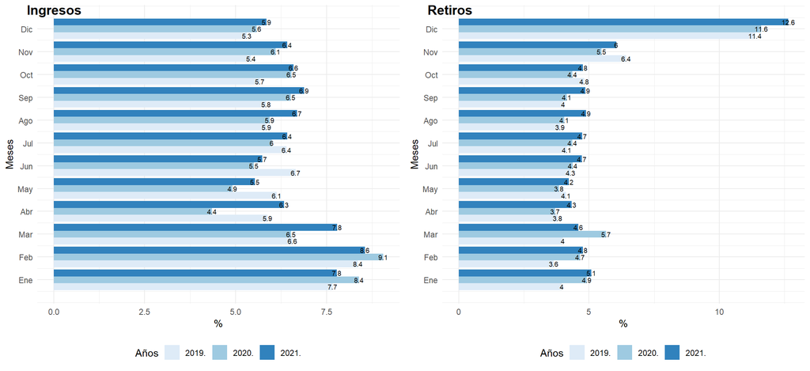

Variaciones anuales de novedades de ingreso y retiro

| Mes | Ingresos 2019 | Ingresos 2020 | Ingresos 2021 | Retiros 2019 | Retiros 2020 | Retiros 2021 |
| --- | --- | --- | --- | --- | --- | --- |
| Ene | -11,3% | 11,8% | -7,2% | 27,7% | 27,2% | 3,7% |
| Feb | 32,1% | 10,0% | -5,7% | 45,5% | 29,6% | 2,2% |
| Mar | 47,7% | -0,9% | 22,1% | 60,0% | 41,2% | -17,1% |
| Abr | 36,7% | -28,9% | 54,8% | 41,3% | -6,5% | 24,7% |
| May | 47,3% | -23,6% | 19,7% | 50,8% | -11,1% | 16,6% |
| Jun | 55,8% | -21,6% | 10,8% | 24,6% | -3,4% | 15,0% |
| Jul | 22,0% | -11,2% | 13,5% | 14,3% | -0,2% | 15,3% |
| Ago | -3,0% | -3,7% | 19,5% | 23,4% | -1,1% | 27,8% |
| Sep | -0,8% | 7,1% | 10,9% | 8,8% | -0,8% | 23,0% |
| Oct | 2,4% | 12,1% | 4,7% | 41,6% | -12,4% | 13,6% |
| Nov | 8,5% | 11,1% | 7,7% | 27,7% | -15,9% | 13,1% |
| Dic | 11,3% | 6,0% | 3,5% | 47,8% | 3,0% | 7,5% |

| Mes | Ingresos 2019 | Ingresos 2020 | Ingresos 2021 | Retiros 2019 | Retiros 2020 | Retiros 2021 |
| --- | --- | --- | --- | --- | --- | --- |
| Ene | 48,2% | 49,0% | 30,4% | -52,6% | -59,2% | -59,0% |
| Feb | 13,5% | 11,6% | 13,5% | -3,9% | -2,1% | -3,5% |
| Mar | -19,7% | -27,6% | -6,3% | 11,9% | 21,9% | -1,1% |
| Abr | -9,8% | -35,3% | -17,9% | -4,3% | -36,6% | -4,6% |
| May | 5,6% | 13,4% | -12,4% | 10,1% | 4,6% | -2,1% |
| Jun | 9,9% | 12,8% | 4,5% | 5,3% | 14,4% | 12,8% |
| Jul | -2,9% | 10,0% | 12,7% | -2,6% | 0,7% | 0,9% |
| Ago | -8,0% | -0,2% | 5,1% | -5,5% | -6,3% | 3,9% |
| Sep | 0,5% | 11,7% | 3,7% | 3,9% | 4,1% | 0,2% |
| Oct | -2,5% | 2,0% | -3,7% | 20,9% | 6,8% | -1,4% |
| Nov | -4,9% | -5,7% | -3,0% | 32,4% | 27,0% | 26,5% |
| Dic | -5,5% | -9,9% | -13,3% | 70,7% | 109,1% | 98,7% |

# Seguimiento longitudinal

## Sector privado

Para Diciembre de 2021 se encontraron, 8.674.745 cotizantes del sector privado, con una variación mensual de -2.3% que es sup es mas alta a la obtenida en 2020 y 2019 con -0.4% y -1.8% respectivamente.

Matriz resumen de la dinamica pareada entre Diciembre y Noviembre de 2021

| Mes | Entran | Permanecen | Salen | Salen con Retiro | Salen sin Retiro | Entran (%) | Salen (%) |
| --- | --- | --- | --- | --- | --- | --- | --- |
| <=1SMMLV | 466.437 | 2.510.233 | 564.629 | 506.624 | 58.005 | 15.67% | 18.36% |
| 1-2_SMMLV | 103.985 | 3.518.510 | 144.505 | 120.357 | 24.148 | 2.87% | 3.94% |
| 2-3_SMMLV | 14.441 | 846.607 | 34.074 | 30.869 | 3.205 | 1.68% | 3.87% |
| 3-4_SMMLV | 5.522 | 403.105 | 12.963 | 11.699 | 1.264 | 1.35% | 3.12% |
| 4-5_SMMLV | 2.771 | 223.911 | 6.568 | 5.922 | 646 | 1.22% | 2.85% |
| >5_SMMLV | 5.048 | 604.498 | 13.313 | 12.031 | 1.282 | 0.83% | 2.15% |
| Total | 598.204 | 8.106.864 | 776.052 | 687.502 | 88.550 | 6.87% | 8.74% |

Matriz resumen de la dinamica pareada entre Noviembre y Octubre de 2021

| Mes | Entran | Permanecen | Salen | Salen con Retiro | Salen sin Retiro | Entran (%) | Salen (%) |
| --- | --- | --- | --- | --- | --- | --- | --- |
| <=1SMMLV | 603.779 | 2.606.625 | 503.082 | 467.203 | 35.879 | 18.81% | 16.18% |
| 1-2_SMMLV | 93.437 | 3.520.924 | 106.911 | 95.385 | 11.526 | 2.59% | 2.95% |
| 2-3_SMMLV | 16.116 | 846.606 | 22.404 | 21.093 | 1.311 | 1.87% | 2.58% |
| 3-4_SMMLV | 6.402 | 405.542 | 9.053 | 8.476 | 577 | 1.55% | 2.18% |
| 4-5_SMMLV | 3.363 | 222.767 | 4.857 | 4.575 | 282 | 1.49% | 2.13% |
| >5_SMMLV | 5.596 | 538.108 | 12.379 | 11.843 | 536 | 1.03% | 2.25% |
| Total | 728.693 | 8.140.572 | 658.686 | 608.575 | 50.111 | 8.22% | 7.49% |

Un aumento de 177.848 salidas con relación a las entradas, que es superior a las registradas en 2020 y 2019 con diferencias de 41.066 y 157.512 pero por debajo de las registradas en 2018 que fueron de 196.849

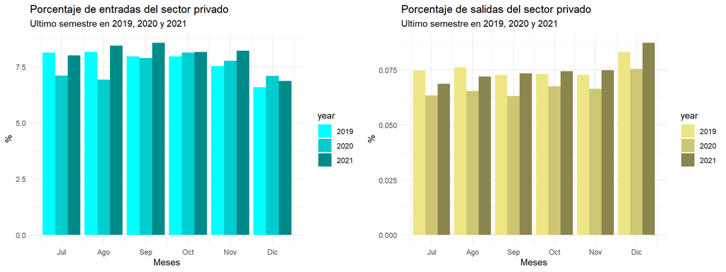

| Mes | Entran | Permanecen | Salen | Salen con Retiro | Salen sin Retiro | Entran (%) | Salen (%) |
| --- | --- | --- | --- | --- | --- | --- | --- |
| <=1SMMLV | 460.818 | 2.350.465 | 463.862 | 443.544 | 20.318 | 16.39% | 16.48% |
| 1-2_SMMLV | 91.864 | 3.322.645 | 105.285 | 98.880 | 6.405 | 2.69% | 3.07% |
| 2-3_SMMLV | 11.618 | 773.139 | 24.298 | 23.664 | 634 | 1.48% | 3.05% |
| 3-4_SMMLV | 4.666 | 355.769 | 8.904 | 8.634 | 270 | 1.29% | 2.44% |
| 4-5_SMMLV | 2.259 | 193.515 | 4.475 | 4.347 | 128 | 1.15% | 2.26% |
| >5_SMMLV | 4.039 | 549.362 | 9.506 | 9.191 | 315 | 0.73% | 1.7% |
| Total | 575.264 | 7.544.895 | 616.330 | 588.260 | 28.070 | 7.08% | 7.55% |

| Mes | Entran | Permanecen | Salen | Salen con Retiro | Salen sin Retiro | Entran (%) | Salen (%) |
| --- | --- | --- | --- | --- | --- | --- | --- |
| <=1SMMLV | 443.317 | 2.447.461 | 520.396 | 496.727 | 23.669 | 15.34% | 17.53% |
| 1-2_SMMLV | 85.621 | 3.427.877 | 129.391 | 121.589 | 7.802 | 2.44% | 3.64% |
| 2-3_SMMLV | 11.599 | 780.328 | 30.435 | 29.538 | 897 | 1.46% | 3.75% |
| 3-4_SMMLV | 4.641 | 380.320 | 11.514 | 11.067 | 447 | 1.21% | 2.94% |
| 4-5_SMMLV | 2.318 | 208.713 | 5.554 | 5.345 | 209 | 1.1% | 2.59% |
| >5_SMMLV | 3.924 | 574.148 | 11.642 | 11.059 | 583 | 0.68% | 1.99% |
| Total | 551.420 | 7.818.847 | 708.932 | 675.325 | 33.607 | 6.59% | 8.31% |

De las relaciones laborales que permanecieron, el 10.38%,13.8% y 75.83% disminuyen, aumentan y permanecen en promedio el rango salarial para Diciembre de 2021. En 2020 y en 2019 las disminuciones, aumentos y permanencias se presentan en la siguientes magnitudes 9.89%,13.87% y 76.24%, y 10.67%,14.19% y 75.14%.

Matriz de trancisión entre Noviembre y Diciembre de 2021

| <=1SMMLV | 1-2SMMLV | 2-3SMMLV | 3-4SMMLV | 4-5SMMLV | >5SMMLV | Disminuyen % | Incrementan % |
| --- | --- | --- | --- | --- | --- | --- | --- |
| 84.39% | 14.82% | 0.58% | 0.13% | 0.04% | 0.04% | 0% | 15.61% |
| 7.3% | 86.55% | 5.23% | 0.62% | 0.16% | 0.13% | 7.3% | 6.15% |
| 1.51% | 12.74% | 70.78% | 10.25% | 2.46% | 2.26% | 14.25% | 14.97% |
| 0.62% | 2.26% | 12.49% | 63.78% | 10.81% | 10.05% | 15.37% | 20.86% |
| 0.39% | 0.99% | 3.71% | 11.57% | 58.15% | 25.18% | 16.66% | 25.18% |
| 0.16% | 0.32% | 0.85% | 2.48% | 4.89% | 91.31% | 8.69% | 0% |

Matriz de trancisión entre Noviembre y Diciembre de 2020

| <=1SMMLV | 1-2SMMLV | 2-3SMMLV | 3-4SMMLV | 4-5SMMLV | >5SMMLV | Disminuyen % | Incrementan % |
| --- | --- | --- | --- | --- | --- | --- | --- |
| 85.81% | 13.49% | 0.52% | 0.11% | 0.03% | 0.04% | 0% | 14.19% |
| 6.87% | 87.15% | 5.1% | 0.59% | 0.16% | 0.13% | 6.87% | 5.98% |
| 1.5% | 11.91% | 71.67% | 9.94% | 2.44% | 2.56% | 13.4% | 14.93% |
| 0.6% | 2.35% | 11.79% | 63.64% | 10.58% | 11.05% | 14.74% | 21.63% |
| 0.35% | 1.03% | 3.54% | 11.41% | 57.18% | 26.48% | 16.34% | 26.48% |
| 0.15% | 0.34% | 0.75% | 2.22% | 4.53% | 92.01% | 7.99% | 0% |

| <=1SMMLV | 1-2SMMLV | 2-3SMMLV | 3-4SMMLV | 4-5SMMLV | >5SMMLV | Disminuyen % | Incrementan % |
| --- | --- | --- | --- | --- | --- | --- | --- |
| 84.9% | 14.42% | 0.48% | 0.12% | 0.05% | 0.04% | 0% | 15.1% |
| 8.46% | 85.46% | 5.13% | 0.66% | 0.16% | 0.12% | 8.46% | 6.08% |
| 1.58% | 13.19% | 69.22% | 10.75% | 2.7% | 2.55% | 14.77% | 16.01% |
| 0.76% | 2.52% | 12.04% | 63.07% | 10.65% | 10.96% | 15.32% | 21.61% |
| 0.47% | 1.07% | 3.78% | 11.41% | 56.93% | 26.34% | 16.73% | 26.34% |
| 0.21% | 0.35% | 0.86% | 2.5% | 4.83% | 91.26% | 8.74% | 0% |

### Actividad económica

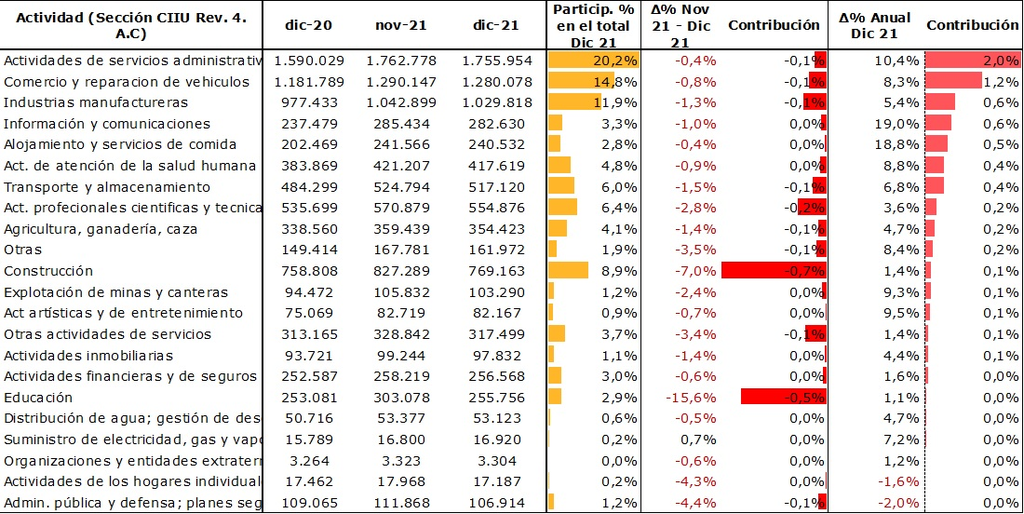

## Independientes

Para Diciembre de 2021 se encontraron 2.181.666 cotizantes del sector privado, con una variación mensual de -4.2% que es mas alta a la obtenida en 2020 y 2019 con -1.3% y -3.5% respectivamente.

Matriz resumen de la dinamica pareada entre Diciembre y Noviembre de 2021

| Mes | Entran | Permanecen | Salen | Salen con Retiro | Salen sin Retiro | Entran (%) | Salen (%) |
| --- | --- | --- | --- | --- | --- | --- | --- |
| <=1SMMLV | 95.053 | 1.404.834 | 160.948 | 80.674 | 80.274 | 6.34% | 10.28% |
| 1-2_SMMLV | 16.079 | 408.786 | 40.791 | 14.660 | 26.131 | 3.78% | 9.07% |
| 2-3_SMMLV | 4.128 | 116.031 | 8.169 | 2.543 | 5.626 | 3.44% | 6.58% |
| 3-4_SMMLV | 1.939 | 50.765 | 2.940 | 952 | 1.988 | 3.68% | 5.47% |
| 4-5_SMMLV | 925 | 23.425 | 1.305 | 446 | 859 | 3.8% | 5.28% |
| >5_SMMLV | 3.739 | 55.962 | 3.062 | 1.327 | 1.735 | 6.26% | 5.19% |
| Total | 121.863 | 2.059.803 | 217.215 | 100.602 | 116.613 | 5.59% | 9.54% |

Matriz resumen de la dinamica pareada entre Diciembre y Noviembre de 2020

| Mes | Entran | Permanecen | Salen | Salen con Retiro | Salen sin Retiro | Entran (%) | Salen (%) |
| --- | --- | --- | --- | --- | --- | --- | --- |
| <=1SMMLV | 89.933 | 1.440.018 | 110.848 | 70.291 | 40.557 | 5.88% | 7.15% |
| 1-2_SMMLV | 15.637 | 399.786 | 26.530 | 13.081 | 13.449 | 3.76% | 6.22% |
| 2-3_SMMLV | 4.343 | 116.019 | 5.155 | 2.242 | 2.913 | 3.61% | 4.25% |
| 3-4_SMMLV | 1.603 | 46.237 | 1.584 | 721 | 863 | 3.35% | 3.31% |
| 4-5_SMMLV | 1.048 | 21.739 | 763 | 359 | 404 | 4.6% | 3.39% |
| >5_SMMLV | 4.306 | 51.975 | 1.792 | 1.098 | 694 | 7.65% | 3.33% |
| Total | 116.870 | 2.075.774 | 146.672 | 87.792 | 58.880 | 5.33% | 6.6% |

Matriz resumen de la dinamica pareada entre Diciembre y Noviembre de 2019

| Mes | Entran | Permanecen | Salen | Salen con Retiro | Salen sin Retiro | Entran (%) | Salen (%) |
| --- | --- | --- | --- | --- | --- | --- | --- |
| <=1SMMLV | 82.566 | 1.449.509 | 139.231 | 90.701 | 48.530 | 5.39% | 8.76% |
| 1-2_SMMLV | 14.001 | 375.120 | 34.644 | 18.373 | 16.271 | 3.6% | 8.45% |
| 2-3_SMMLV | 3.614 | 111.313 | 6.506 | 3.203 | 3.303 | 3.14% | 5.52% |
| 3-4_SMMLV | 1.432 | 48.590 | 1.939 | 935 | 1.004 | 2.86% | 3.84% |
| 4-5_SMMLV | 985 | 23.515 | 861 | 456 | 405 | 4.02% | 3.53% |
| >5_SMMLV | 3.878 | 53.114 | 1.963 | 1.129 | 834 | 6.8% | 3.56% |
| Total | 106.476 | 2.061.161 | 185.144 | 114.797 | 70.347 | 4.91% | 8.24% |

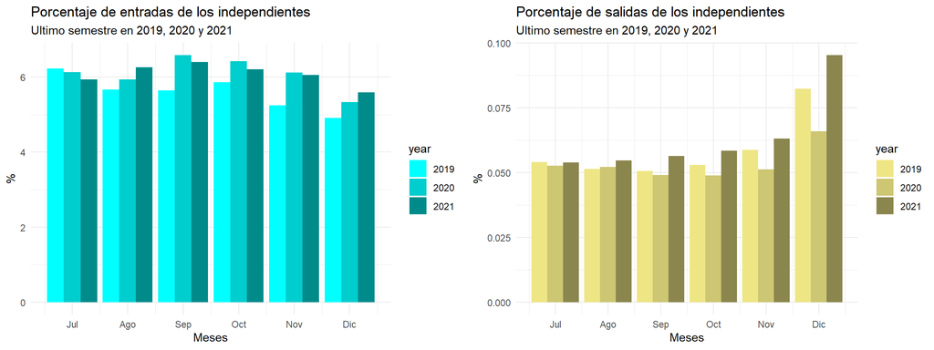

### Actividad económica

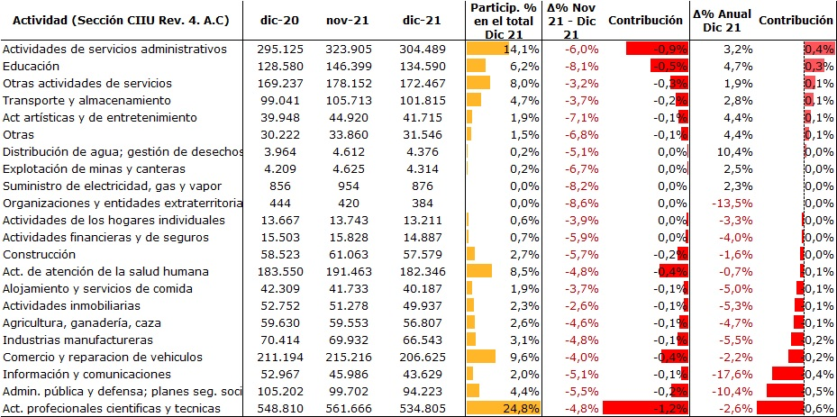

# Monto de cotización

## Dependientes

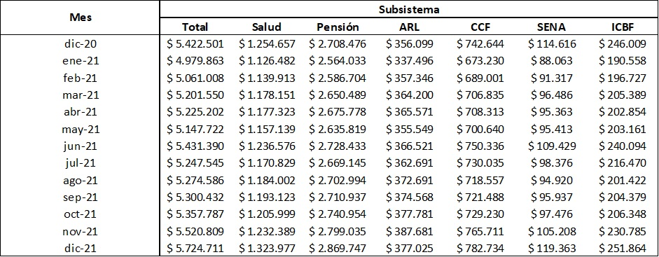

## Independientes

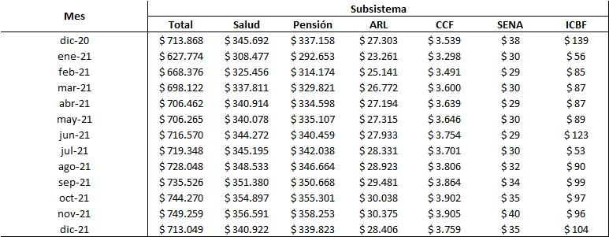

[figure not shown]